# 500_83_get_mixed_effect_model_results.R

paul

2020-03-13

# Preamble

This code commentary is included in the R code itself and can be rendered at any stage using `rmarkdown::render ("/Users/paul/Documents/CU_combined/Github/500_83_get_mixed_effect_model_results.R", clean = TRUE, output_format = "html_notebook")`. Please check the session info at the end of the document for further notes on the coding environment.

# Environment preparation

Empty buffer.

```r
rm(list=ls())
```

Load Packages

```r
library ("tidyverse") # dplyr and friends
library ("ggplot2")   # for ggCaterpillar
library ("gdata")     # matrix functions
```

[output not shown]

[output not shown]

[output not shown]

```r
library ("reshape2")  # melting
library ("lme4")      # mixed effect model
library ("sjPlot")    # mixed effect model - with plotting
library ("cowplot")   # exporting ggplots
```

[output not shown]

[output not shown]

[output not shown]

```r
library ("formula.tools") # better formatting of formulas
```

```
formula.tools-1.7.1 - Copyright © 2020 Decision Patterns
```

```r
library ("stringr")    # better string concatenation
library ("magrittr")  # back-piping (only used for type conversion)
library ("knitr")   # to output results table
library("rmarkdown") # to output results table
library("kableExtra") # better table formatting in this script
```

Functions

```r
# Loaded from helper script:
source("/Users/paul/Documents/CU_combined/Github/500_00_functions.R")
```

“Not in” function

```r
`%!in%` = Negate(`%in%`)
```

Function to subset data to fit model variables. Currently there are more incomplete cases among Notre-Dame predictors then among Cornell predictors. Consider running an extra analysis with Cornell data trimmed so as to match Notre Dame data.

```r
match_data_to_formula <- function (formula_item, data_item, path_and_basename){

  # package loading
  require ("tidyverse")
  require ("openxlsx")

  # message
  message("\nData is subset to fit model variables, but currently there are more incomplete cases among Notre-Dame predictors then among Cornell predictors. Consider running an extra analysis with Cornell data trimmed so as to match Notre Dame data.")

  # Setting types
  #   for debugging only
  # print(head(data_item))

  message("- Setting types.")
  cols <- c("PORT", "DEST", "ECO_PORT", "ECO_DEST", "ECO_DIFF")
  data_item[cols] <- lapply(data_item[cols], as.factor)

  #   for debugging only
  # print(head(data_item))

  # remove superflous columns
  vars_to_keep <- all.vars (formula_item)

  # create names for unmodified files (before subsetting)
  path_unmod_file <-  paste(path_and_basename, "_unmodified_input_data.xlsx", sep = "", collapse = NULL)


  # diagnostic message
  message("- Input dimensions are: ", paste0( (dim(data_item)), " "),  " written to \"", path_unmod_file, "\"")


  # and write
  write.xlsx(data_item, file = path_unmod_file, colNames = TRUE, borders = "surrounding")

  message("- Removed variables are: ", paste0( names(data_item)[which(names(data_item) %!in% vars_to_keep)], " "), ".")
  message("- Kept variables are: ", paste0(vars_to_keep, " "), ".")

  data_item <- data_item %>% select(all_of(vars_to_keep))

  message("- Intermediate dimensions are: ", paste0( (dim(data_item)), " "), ".")

  # remove superflous rows
  message("- Undefined rows have been removed, less predictors available then UNIFRAC responses. Check output files.")

  data_item <- data_item %>% filter(complete.cases(.))

  # create names for modified files (after subsetting)
  path_mod_file <-  paste(path_and_basename, "_subset_input_table.xlsx", sep = "", collapse = NULL)

  # diagnostic message.
  message("- Final dimensions are: ", paste0( (dim(data_item)), " "), " written to \"", path_mod_file, "\"")


  # and write
  write.xlsx(data_item, file = path_mod_file, colNames = TRUE, borders = "surrounding")

  # return table object suitable for modelling with model formula
  return(data_item)

}
```

Calculate random effect model results

```r
calculate_model <- function(formula_item, data_item){

  message("\nModelling function received variables: ", paste0(names(data_item) , " "), ".")
  message("   ... dimensions: ", paste0( (dim(data_item)), " "), ".")
  message("   ... formula: ", paste0(formula_item , " "), "." )

  model <- lmer(formula_item, data = data_item, REML=FALSE)

  return(model)
}
```

# Model definitions

## Define full models

following `https://stackoverflow.com/questions/25312818/using-lapply-to-fit-multiple-model-how-to-keep-the-model-formula-self-contain`

```r
full_formulae <- list(

  # Model A:
  as.formula(RESP_UNIFRAC ~ VOY_FREQ + PRED_ENV + ECO_DIFF + (1 | PORT) + (1 | DEST)),

  # Model B:
  as.formula(RESP_UNIFRAC ~ B_FON_NOECO + ECO_DIFF + (1 | PORT) + (1 | DEST)),

  # Model C:
  # as.formula(RESP_UNIFRAC ~ B_HON_NOECO + ECO_DIFF + (1 | PORT) + (1 | DEST)),

  # Model D:
  as.formula(RESP_UNIFRAC ~ B_FON_NOECO_NOENV + PRED_ENV + ECO_DIFF + (1 | PORT) + (1 | DEST))

  # Model E:
  # as.formula(RESP_UNIFRAC ~ B_HON_NOECO_NOENV + PRED_ENV + ECO_DIFF + (1 | PORT) + (1 | DEST))
)
```

## Define null models

For Anova comparison. Order *must* be the same as in list `full_models`.

```r
null_formulae <- list(

  # Model A:
  as.formula(RESP_UNIFRAC ~ VOY_FREQ + ECO_DIFF + (1 | PORT) + (1 | DEST)),

  # Model B:
  as.formula(RESP_UNIFRAC ~ ECO_DIFF + (1 | PORT) + (1 | DEST)),

  # Model C:
  # as.formula(RESP_UNIFRAC ~ ECO_DIFF + (1 | PORT) + (1 | DEST)),

  # Model D:
  as.formula(RESP_UNIFRAC ~ PRED_ENV + ECO_DIFF + (1 | PORT) + (1 | DEST))

  # Model E:
  # as.formula(RESP_UNIFRAC ~ PRED_ENV + ECO_DIFF + (1 | PORT) + (1 | DEST))

)
```

# Read in and format data

Please refer to project README.md file for further details on previous processing steps (dated 31-Jan-2020).

```r
# define file path components for listing
model_input_folder <- "/Users/paul/Documents/CU_combined/Zenodo/Results"
model_input_pattern <- glob2rx("??_results_euk_asv00*UNIF_model_data_*_with_hon_info.csv")

# read all file into lists for `lapply()` usage
model_input_files <- list.files(path=model_input_folder,
  pattern = model_input_pattern, full.names = TRUE)

# store all tables in list and save input filenames alongside - skipping "X1"
#  in case previous tables have column numbers, which they should not have anymore.
model_input_data <- suppressWarnings(lapply(model_input_files,
  function(listed_file)  read_csv(listed_file, col_types = cols('X1' = col_skip()))))
names(model_input_data) <- model_input_files

# After phone call 6.2.2020 keep only one dataset in list.
# After email call 27.2.2020 keep only one dataset in list. Same as previous.

# subset datasets
model_input_data <- list(model_input_data[[2]], model_input_data[[4]])

# subset names
model_input_files <- list(model_input_files[[2]], model_input_files[[4]])
print(model_input_files)
```

```
[[1]]
[1] "/Users/paul/Documents/CU_combined/Zenodo/Results/01_results_euk_asv00_deep_UNIF_model_data_2020-Mar-13-13-16-52_with_hon_info.csv"

[[2]]
[1] "/Users/paul/Documents/CU_combined/Zenodo/Results/05_results_euk_asv00_shal_UNIF_model_data_2020-Mar-13-13-17-18_with_hon_info.csv"
```

```r
# set names
names(model_input_data) <- model_input_files
```

# Obtaining modelling results

## Initialize results table

So that it can be filled in the loop.

```r
analysis_summaries <- expand.grid(seq(model_input_data), seq(full_formulae))
analysis_summaries <- as_tibble(analysis_summaries)
analysis_summaries <- setNames(analysis_summaries, c("DIDX", "FIDX"))
analysis_summaries <- analysis_summaries %>% add_column(AKAI = 0, PVAL = 0, FRML = 0, DATA = 0, BASENAME = 0)

analysis_summaries$AKAI  %<>% as.double
analysis_summaries$DATA %<>% as.character
analysis_summaries$FRML  %<>% as.character
analysis_summaries$PVAL  %<>% as.double
analysis_summaries$BASENAME %<>% as.character

# use this approach to get around the loop - later
#   define all possible combinations for mapply call
#   for later - starting point
#   analysis_combinations <- expand.grid(seq(model_input_data), seq(full_formulae))
#   setNames(analysis_combinations, c("model_index", "formula_index"))
#   for later - starting point
#   list(model_input_data, full_formulae)
```

## Calculating Results

```
°º¤ø,¸¸,ø¤º°`°º¤ø,¸,ø¤°º¤ø,¸¸,ø¤º°`°º¤ø,¸ °º¤ø,¸¸,ø¤º°`°º¤ø,¸,ø¤°º¤ø,¸¸,ø¤º°`°º¤ø,¸ °º¤ø,¸¸,ø¤º°`°º¤ø,¸,ø¤°º¤ø,¸¸,ø¤º°`°º¤ø,¸
```

```
Starting new analysis, with data index DIDX "1" and formula index FIDX "1" in Summary Tables.
```

```
Using formula: RESP_UNIFRAC ~ VOY_FREQ + PRED_ENV + ECO_DIFF + (1 | PORT) + (1 | DEST) with data: 01_results_euk_asv00_deep_UNIF_model_data_2020-Mar-13-13-16-52_with_hon_info.csv.
```

```
Data is subset to fit model variables, but currently there are more incomplete cases among Notre-Dame predictors then among Cornell predictors. Consider running an extra analysis with Cornell data trimmed so as to match Notre Dame data.
```

```
- Setting types.
```

```
- Input dimensions are: 210 20  written to "/Users/paul/Documents/CU_combined/Zenodo/Results/20201103_Rscrpt-500-83_mme_result_DIDX_1_FIDX_1__unmodified_input_data.xlsx"
```

```
- Removed variables are: ECO_PORT ECO_DEST B_FON_NOECO B_HON_NOECO B_FON_SMECO B_HON_SMECO B_FON_NOECO_NOENV B_HON_NOECO_NOENV F_FON_NOECO F_HON_NOECO F_FON_SMECO F_HON_SMECO F_FON_NOECO_NOENV F_HON_NOECO_NOENV .
```

```
- Kept variables are: RESP_UNIFRAC VOY_FREQ PRED_ENV ECO_DIFF PORT DEST .
```

```
- Intermediate dimensions are: 210 6 .
```

```
- Undefined rows have been removed, less predictors available then UNIFRAC responses. Check output files.
```

```
- Final dimensions are: 210 6  written to "/Users/paul/Documents/CU_combined/Zenodo/Results/20201103_Rscrpt-500-83_mme_result_DIDX_1_FIDX_1__subset_input_table.xlsx"
```

```
Modelling function received variables: RESP_UNIFRAC VOY_FREQ PRED_ENV ECO_DIFF PORT DEST .
```

```
   ... dimensions: 210 6 .
```

```
   ... formula: RESP_UNIFRAC ~ VOY_FREQ + PRED_ENV + ECO_DIFF + (1 | PORT) + (1 | DEST) .
```

```
Modelling function received variables: RESP_UNIFRAC VOY_FREQ PRED_ENV ECO_DIFF PORT DEST .
```

```
   ... dimensions: 210 6 .
```

```
   ... formula: RESP_UNIFRAC ~ VOY_FREQ + ECO_DIFF + (1 | PORT) + (1 | DEST) .
```

```
Model Summary:
```

```
Linear mixed model fit by maximum likelihood  ['lmerMod']
Formula: RESP_UNIFRAC ~ VOY_FREQ + PRED_ENV + ECO_DIFF + (1 | PORT) +      (1 | DEST)
   Data: data_item

     AIC      BIC   logLik deviance df.resid
  -442.4   -418.9    228.2   -456.4      203

Scaled residuals:
     Min       1Q   Median       3Q      Max
-2.73636 -0.60083 -0.04165  0.63250  2.55889

Random effects:
 Groups   Name        Variance  Std.Dev.
 PORT     (Intercept) 0.0014765 0.03842
 DEST     (Intercept) 0.0009713 0.03117
 Residual             0.0054088 0.07354
Number of obs: 210, groups:  PORT, 20; DEST, 20

Fixed effects:
              Estimate Std. Error t value
(Intercept)  5.385e-01  1.679e-02  32.076
VOY_FREQ     9.360e-06  3.876e-06   2.415
PRED_ENV     6.287e-02  5.946e-03  10.573
ECO_DIFFTRUE 9.547e-02  1.488e-02   6.416

Correlation of Fixed Effects:
            (Intr) VOY_FR PRED_E
VOY_FREQ    -0.185
PRED_ENV    -0.330  0.003
ECO_DIFFTRU -0.334  0.234 -0.445
fit warnings:
Some predictor variables are on very different scales: consider rescaling
```

```
Model Coefficients from Summary:
```

```
                 Estimate   Std. Error   t value
(Intercept)  5.384500e-01 1.678696e-02 32.075501
VOY_FREQ     9.360345e-06 3.876358e-06  2.414726
PRED_ENV     6.286911e-02 5.945926e-03 10.573476
ECO_DIFFTRUE 9.546642e-02 1.488010e-02  6.415712
```

```
Attempting Model ANOVA:
```

```
Data: data_item
Models:
null_model: RESP_UNIFRAC ~ VOY_FREQ + ECO_DIFF + (1 | PORT) + (1 | DEST)
full_model: RESP_UNIFRAC ~ VOY_FREQ + PRED_ENV + ECO_DIFF + (1 | PORT) +
full_model:     (1 | DEST)
           Df     AIC     BIC logLik deviance  Chisq Chi Df Pr(>Chisq)
null_model  6 -359.29 -339.21 185.64  -371.29
full_model  7 -442.35 -418.92 228.18  -456.35 85.062      1  < 2.2e-16 ***
---
Signif. codes:  0 '***' 0.001 '**' 0.01 '*' 0.05 '.' 0.1 ' ' 1
```

```
Plotting Model Coefficients:
```

```
°º¤ø,¸¸,ø¤º°`°º¤ø,¸,ø¤°º¤ø,¸¸,ø¤º°`°º¤ø,¸ °º¤ø,¸¸,ø¤º°`°º¤ø,¸,ø¤°º¤ø,¸¸,ø¤º°`°º¤ø,¸ °º¤ø,¸¸,ø¤º°`°º¤ø,¸,ø¤°º¤ø,¸¸,ø¤º°`°º¤ø,¸
```

```
Starting new analysis, with data index DIDX "2" and formula index FIDX "1" in Summary Tables.
```

```
Using formula: RESP_UNIFRAC ~ VOY_FREQ + PRED_ENV + ECO_DIFF + (1 | PORT) + (1 | DEST) with data: 05_results_euk_asv00_shal_UNIF_model_data_2020-Mar-13-13-17-18_with_hon_info.csv.
```

```
Data is subset to fit model variables, but currently there are more incomplete cases among Notre-Dame predictors then among Cornell predictors. Consider running an extra analysis with Cornell data trimmed so as to match Notre Dame data.
```

```
- Setting types.
```

```
- Input dimensions are: 210 20  written to "/Users/paul/Documents/CU_combined/Zenodo/Results/20201103_Rscrpt-500-83_mme_result_DIDX_2_FIDX_1__unmodified_input_data.xlsx"
```

```
- Removed variables are: ECO_PORT ECO_DEST B_FON_NOECO B_HON_NOECO B_FON_SMECO B_HON_SMECO B_FON_NOECO_NOENV B_HON_NOECO_NOENV F_FON_NOECO F_HON_NOECO F_FON_SMECO F_HON_SMECO F_FON_NOECO_NOENV F_HON_NOECO_NOENV .
```

```
- Kept variables are: RESP_UNIFRAC VOY_FREQ PRED_ENV ECO_DIFF PORT DEST .
```

```
- Intermediate dimensions are: 210 6 .
```

```
- Undefined rows have been removed, less predictors available then UNIFRAC responses. Check output files.
```

```
- Final dimensions are: 210 6  written to "/Users/paul/Documents/CU_combined/Zenodo/Results/20201103_Rscrpt-500-83_mme_result_DIDX_2_FIDX_1__subset_input_table.xlsx"
```

```
Modelling function received variables: RESP_UNIFRAC VOY_FREQ PRED_ENV ECO_DIFF PORT DEST .
```

```
   ... dimensions: 210 6 .
```

```
   ... formula: RESP_UNIFRAC ~ VOY_FREQ + PRED_ENV + ECO_DIFF + (1 | PORT) + (1 | DEST) .
```

```
Modelling function received variables: RESP_UNIFRAC VOY_FREQ PRED_ENV ECO_DIFF PORT DEST .
```

```
   ... dimensions: 210 6 .
```

```
   ... formula: RESP_UNIFRAC ~ VOY_FREQ + ECO_DIFF + (1 | PORT) + (1 | DEST) .
```

```
Model Summary:
```

```
Linear mixed model fit by maximum likelihood  ['lmerMod']
Formula: RESP_UNIFRAC ~ VOY_FREQ + PRED_ENV + ECO_DIFF + (1 | PORT) +      (1 | DEST)
   Data: data_item

     AIC      BIC   logLik deviance df.resid
  -432.1   -408.7    223.1   -446.1      203

Scaled residuals:
    Min      1Q  Median      3Q     Max
-2.8546 -0.6065 -0.0367  0.6616  2.6049

Random effects:
 Groups   Name        Variance  Std.Dev.
 PORT     (Intercept) 0.0013209 0.03634
 DEST     (Intercept) 0.0009189 0.03031
 Residual             0.0057789 0.07602
Number of obs: 210, groups:  PORT, 20; DEST, 20

Fixed effects:
              Estimate Std. Error t value
(Intercept)  5.357e-01  1.677e-02  31.946
VOY_FREQ     9.459e-06  3.995e-06   2.368
PRED_ENV     6.432e-02  6.077e-03  10.584
ECO_DIFFTRUE 9.887e-02  1.531e-02   6.456

Correlation of Fixed Effects:
            (Intr) VOY_FR PRED_E
VOY_FREQ    -0.192
PRED_ENV    -0.341  0.004
ECO_DIFFTRU -0.347  0.232 -0.448
fit warnings:
Some predictor variables are on very different scales: consider rescaling
```

```
Model Coefficients from Summary:
```

```
                 Estimate   Std. Error   t value
(Intercept)  5.356840e-01 1.676850e-02 31.945840
VOY_FREQ     9.458510e-06 3.994554e-06  2.367851
PRED_ENV     6.431841e-02 6.076831e-03 10.584201
ECO_DIFFTRUE 9.886674e-02 1.531293e-02  6.456424
```

```
Attempting Model ANOVA:
```

```
Data: data_item
Models:
null_model: RESP_UNIFRAC ~ VOY_FREQ + ECO_DIFF + (1 | PORT) + (1 | DEST)
full_model: RESP_UNIFRAC ~ VOY_FREQ + PRED_ENV + ECO_DIFF + (1 | PORT) +
full_model:     (1 | DEST)
           Df     AIC     BIC logLik deviance  Chisq Chi Df Pr(>Chisq)
null_model  6 -349.52 -329.44 180.76  -361.52
full_model  7 -432.11 -408.68 223.05  -446.11 84.582      1  < 2.2e-16 ***
---
Signif. codes:  0 '***' 0.001 '**' 0.01 '*' 0.05 '.' 0.1 ' ' 1
```

```
Plotting Model Coefficients:
```

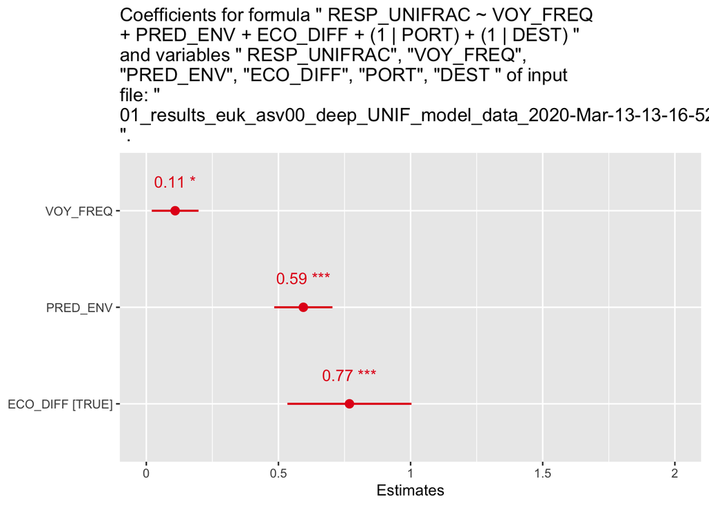

```
°º¤ø,¸¸,ø¤º°`°º¤ø,¸,ø¤°º¤ø,¸¸,ø¤º°`°º¤ø,¸ °º¤ø,¸¸,ø¤º°`°º¤ø,¸,ø¤°º¤ø,¸¸,ø¤º°`°º¤ø,¸ °º¤ø,¸¸,ø¤º°`°º¤ø,¸,ø¤°º¤ø,¸¸,ø¤º°`°º¤ø,¸
```

```
Starting new analysis, with data index DIDX "1" and formula index FIDX "2" in Summary Tables.
```

```
Using formula: RESP_UNIFRAC ~ B_FON_NOECO + ECO_DIFF + (1 | PORT) + (1 | DEST) with data: 01_results_euk_asv00_deep_UNIF_model_data_2020-Mar-13-13-16-52_with_hon_info.csv.
```

```
Data is subset to fit model variables, but currently there are more incomplete cases among Notre-Dame predictors then among Cornell predictors. Consider running an extra analysis with Cornell data trimmed so as to match Notre Dame data.
```

```
- Setting types.
```

```
- Input dimensions are: 210 20  written to "/Users/paul/Documents/CU_combined/Zenodo/Results/20201103_Rscrpt-500-83_mme_result_DIDX_1_FIDX_2__unmodified_input_data.xlsx"
```

```
- Removed variables are: PRED_ENV ECO_PORT ECO_DEST VOY_FREQ B_HON_NOECO B_FON_SMECO B_HON_SMECO B_FON_NOECO_NOENV B_HON_NOECO_NOENV F_FON_NOECO F_HON_NOECO F_FON_SMECO F_HON_SMECO F_FON_NOECO_NOENV F_HON_NOECO_NOENV .
```

```
- Kept variables are: RESP_UNIFRAC B_FON_NOECO ECO_DIFF PORT DEST .
```

```
- Intermediate dimensions are: 210 5 .
```

```
- Undefined rows have been removed, less predictors available then UNIFRAC responses. Check output files.
```

```
- Final dimensions are: 210 5  written to "/Users/paul/Documents/CU_combined/Zenodo/Results/20201103_Rscrpt-500-83_mme_result_DIDX_1_FIDX_2__subset_input_table.xlsx"
```

```
Modelling function received variables: RESP_UNIFRAC B_FON_NOECO ECO_DIFF PORT DEST .
```

```
   ... dimensions: 210 5 .
```

```
   ... formula: RESP_UNIFRAC ~ B_FON_NOECO + ECO_DIFF + (1 | PORT) + (1 | DEST) .
```

```
Modelling function received variables: RESP_UNIFRAC B_FON_NOECO ECO_DIFF PORT DEST .
```

```
   ... dimensions: 210 5 .
```

```
   ... formula: RESP_UNIFRAC ~ ECO_DIFF + (1 | PORT) + (1 | DEST) .
```

```
Model Summary:
```

```
Linear mixed model fit by maximum likelihood  ['lmerMod']
Formula: RESP_UNIFRAC ~ B_FON_NOECO + ECO_DIFF + (1 | PORT) + (1 | DEST)
   Data: data_item

     AIC      BIC   logLik deviance df.resid
  -359.1   -339.0    185.5   -371.1      204

Scaled residuals:
    Min      1Q  Median      3Q     Max
-2.6710 -0.5680  0.1191  0.5560  2.4626

Random effects:
 Groups   Name        Variance  Std.Dev.
 PORT     (Intercept) 0.0009477 0.03078
 DEST     (Intercept) 0.0003716 0.01928
 Residual             0.0090705 0.09524
Number of obs: 210, groups:  PORT, 20; DEST, 20

Fixed effects:
             Estimate Std. Error t value
(Intercept)   0.60281    0.01666  36.191
B_FON_NOECO   0.04642    0.02631   1.765
ECO_DIFFTRUE  0.16911    0.01676  10.092

Correlation of Fixed Effects:
            (Intr) B_FON_
B_FON_NOECO -0.292
ECO_DIFFTRU -0.739  0.290
```

```
Model Coefficients from Summary:
```

```
               Estimate Std. Error   t value
(Intercept)  0.60280707 0.01665620 36.191156
B_FON_NOECO  0.04642333 0.02630832  1.764588
ECO_DIFFTRUE 0.16911134 0.01675723 10.091841
```

```
Attempting Model ANOVA:
```

```
Data: data_item
Models:
null_model: RESP_UNIFRAC ~ ECO_DIFF + (1 | PORT) + (1 | DEST)
full_model: RESP_UNIFRAC ~ B_FON_NOECO + ECO_DIFF + (1 | PORT) + (1 | DEST)
           Df     AIC     BIC logLik deviance  Chisq Chi Df Pr(>Chisq)
null_model  5 -358.05 -341.31 184.02  -368.05
full_model  6 -359.10 -339.02 185.55  -371.10 3.0502      1    0.08073 .
---
Signif. codes:  0 '***' 0.001 '**' 0.01 '*' 0.05 '.' 0.1 ' ' 1
```

```
Plotting Model Coefficients:
```

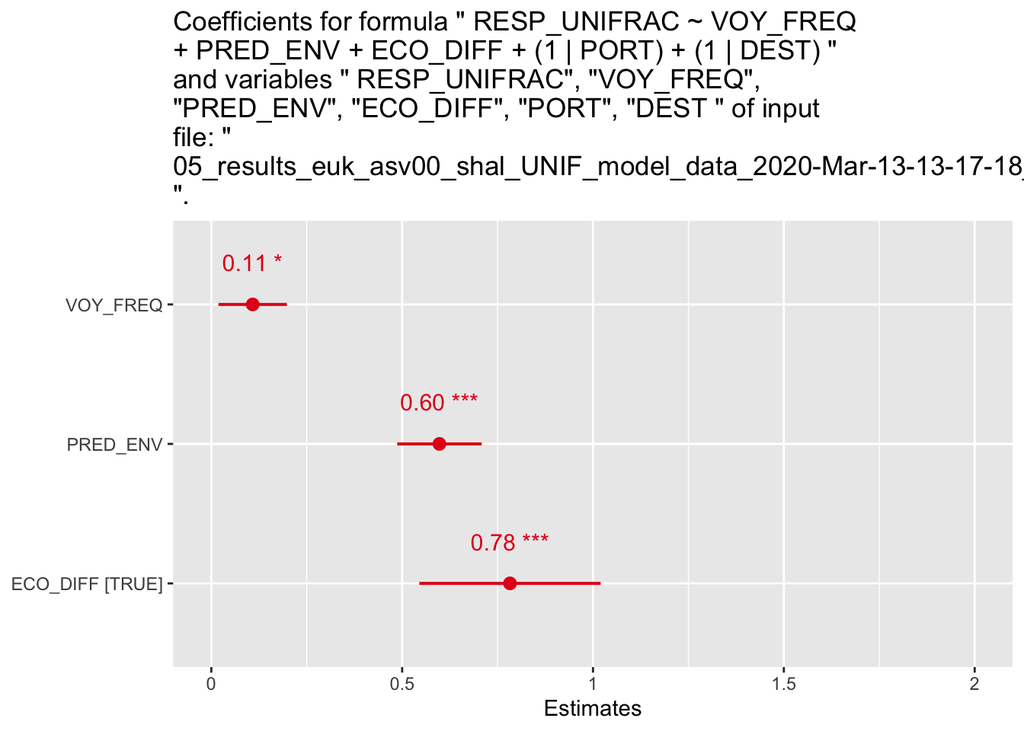

```
°º¤ø,¸¸,ø¤º°`°º¤ø,¸,ø¤°º¤ø,¸¸,ø¤º°`°º¤ø,¸ °º¤ø,¸¸,ø¤º°`°º¤ø,¸,ø¤°º¤ø,¸¸,ø¤º°`°º¤ø,¸ °º¤ø,¸¸,ø¤º°`°º¤ø,¸,ø¤°º¤ø,¸¸,ø¤º°`°º¤ø,¸
```

```
Starting new analysis, with data index DIDX "2" and formula index FIDX "2" in Summary Tables.
```

```
Using formula: RESP_UNIFRAC ~ B_FON_NOECO + ECO_DIFF + (1 | PORT) + (1 | DEST) with data: 05_results_euk_asv00_shal_UNIF_model_data_2020-Mar-13-13-17-18_with_hon_info.csv.
```

```
Data is subset to fit model variables, but currently there are more incomplete cases among Notre-Dame predictors then among Cornell predictors. Consider running an extra analysis with Cornell data trimmed so as to match Notre Dame data.
```

```
- Setting types.
```

```
- Input dimensions are: 210 20  written to "/Users/paul/Documents/CU_combined/Zenodo/Results/20201103_Rscrpt-500-83_mme_result_DIDX_2_FIDX_2__unmodified_input_data.xlsx"
```

```
- Removed variables are: PRED_ENV ECO_PORT ECO_DEST VOY_FREQ B_HON_NOECO B_FON_SMECO B_HON_SMECO B_FON_NOECO_NOENV B_HON_NOECO_NOENV F_FON_NOECO F_HON_NOECO F_FON_SMECO F_HON_SMECO F_FON_NOECO_NOENV F_HON_NOECO_NOENV .
```

```
- Kept variables are: RESP_UNIFRAC B_FON_NOECO ECO_DIFF PORT DEST .
```

```
- Intermediate dimensions are: 210 5 .
```

```
- Undefined rows have been removed, less predictors available then UNIFRAC responses. Check output files.
```

```
- Final dimensions are: 210 5  written to "/Users/paul/Documents/CU_combined/Zenodo/Results/20201103_Rscrpt-500-83_mme_result_DIDX_2_FIDX_2__subset_input_table.xlsx"
```

```
Modelling function received variables: RESP_UNIFRAC B_FON_NOECO ECO_DIFF PORT DEST .
```

```
   ... dimensions: 210 5 .
```

```
   ... formula: RESP_UNIFRAC ~ B_FON_NOECO + ECO_DIFF + (1 | PORT) + (1 | DEST) .
```

```
Modelling function received variables: RESP_UNIFRAC B_FON_NOECO ECO_DIFF PORT DEST .
```

```
   ... dimensions: 210 5 .
```

```
   ... formula: RESP_UNIFRAC ~ ECO_DIFF + (1 | PORT) + (1 | DEST) .
```

```
Model Summary:
```

```
Linear mixed model fit by maximum likelihood  ['lmerMod']
Formula: RESP_UNIFRAC ~ B_FON_NOECO + ECO_DIFF + (1 | PORT) + (1 | DEST)
   Data: data_item

     AIC      BIC   logLik deviance df.resid
  -349.7   -329.6    180.9   -361.7      204

Scaled residuals:
    Min      1Q  Median      3Q     Max
-2.8338 -0.5849  0.1027  0.5821  2.4277

Random effects:
 Groups   Name        Variance  Std.Dev.
 PORT     (Intercept) 0.0005892 0.02427
 DEST     (Intercept) 0.0002842 0.01686
 Residual             0.0097675 0.09883
Number of obs: 210, groups:  PORT, 20; DEST, 20

Fixed effects:
             Estimate Std. Error t value
(Intercept)   0.60316    0.01636  36.867
B_FON_NOECO   0.04764    0.02702   1.763
ECO_DIFFTRUE  0.17482    0.01715  10.194

Correlation of Fixed Effects:
            (Intr) B_FON_
B_FON_NOECO -0.309
ECO_DIFFTRU -0.784  0.288
convergence code: 0
Model failed to converge with max|grad| = 0.0029728 (tol = 0.002, component 1)
```

```
Model Coefficients from Summary:
```

```
               Estimate Std. Error   t value
(Intercept)  0.60315607 0.01636020 36.867279
B_FON_NOECO  0.04763605 0.02702123  1.762912
ECO_DIFFTRUE 0.17481852 0.01714959 10.193740
```

```
Attempting Model ANOVA:
```

```
Data: data_item
Models:
null_model: RESP_UNIFRAC ~ ECO_DIFF + (1 | PORT) + (1 | DEST)
full_model: RESP_UNIFRAC ~ B_FON_NOECO + ECO_DIFF + (1 | PORT) + (1 | DEST)
           Df     AIC     BIC logLik deviance  Chisq Chi Df Pr(>Chisq)
null_model  5 -348.70 -331.96 179.35  -358.70
full_model  6 -349.73 -329.64 180.86  -361.73 3.0262      1    0.08193 .
---
Signif. codes:  0 '***' 0.001 '**' 0.01 '*' 0.05 '.' 0.1 ' ' 1
```

```
Plotting Model Coefficients:
```

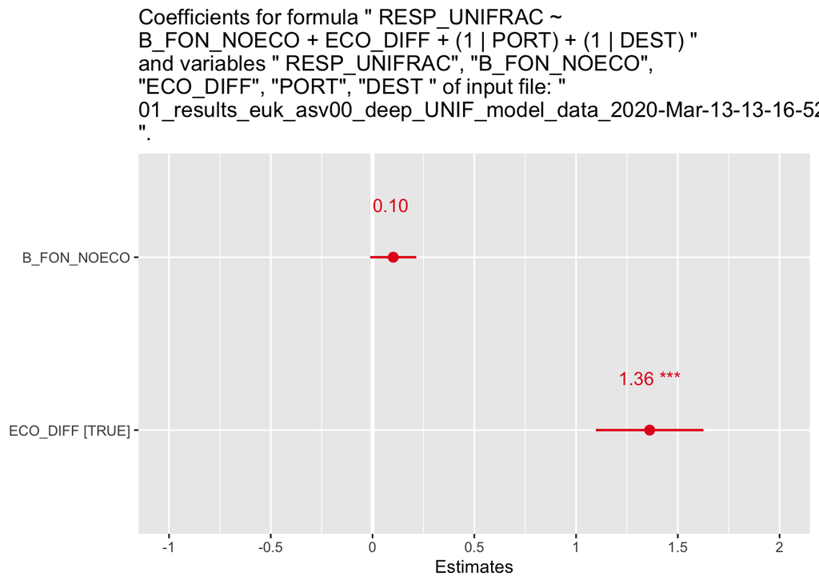

```
°º¤ø,¸¸,ø¤º°`°º¤ø,¸,ø¤°º¤ø,¸¸,ø¤º°`°º¤ø,¸ °º¤ø,¸¸,ø¤º°`°º¤ø,¸,ø¤°º¤ø,¸¸,ø¤º°`°º¤ø,¸ °º¤ø,¸¸,ø¤º°`°º¤ø,¸,ø¤°º¤ø,¸¸,ø¤º°`°º¤ø,¸
```

```
Starting new analysis, with data index DIDX "1" and formula index FIDX "3" in Summary Tables.
```

```
Using formula: RESP_UNIFRAC ~ B_FON_NOECO_NOENV + PRED_ENV + ECO_DIFF + (1 | PORT) + (1 | DEST) with data: 01_results_euk_asv00_deep_UNIF_model_data_2020-Mar-13-13-16-52_with_hon_info.csv.
```

```
Data is subset to fit model variables, but currently there are more incomplete cases among Notre-Dame predictors then among Cornell predictors. Consider running an extra analysis with Cornell data trimmed so as to match Notre Dame data.
```

```
- Setting types.
```

```
- Input dimensions are: 210 20  written to "/Users/paul/Documents/CU_combined/Zenodo/Results/20201103_Rscrpt-500-83_mme_result_DIDX_1_FIDX_3__unmodified_input_data.xlsx"
```

```
- Removed variables are: ECO_PORT ECO_DEST VOY_FREQ B_FON_NOECO B_HON_NOECO B_FON_SMECO B_HON_SMECO B_HON_NOECO_NOENV F_FON_NOECO F_HON_NOECO F_FON_SMECO F_HON_SMECO F_FON_NOECO_NOENV F_HON_NOECO_NOENV .
```

```
- Kept variables are: RESP_UNIFRAC B_FON_NOECO_NOENV PRED_ENV ECO_DIFF PORT DEST .
```

```
- Intermediate dimensions are: 210 6 .
```

```
- Undefined rows have been removed, less predictors available then UNIFRAC responses. Check output files.
```

```
- Final dimensions are: 210 6  written to "/Users/paul/Documents/CU_combined/Zenodo/Results/20201103_Rscrpt-500-83_mme_result_DIDX_1_FIDX_3__subset_input_table.xlsx"
```

```
Modelling function received variables: RESP_UNIFRAC B_FON_NOECO_NOENV PRED_ENV ECO_DIFF PORT DEST .
```

```
   ... dimensions: 210 6 .
```

```
   ... formula: RESP_UNIFRAC ~ B_FON_NOECO_NOENV + PRED_ENV + ECO_DIFF + (1 | PORT) + (1 | DEST) .
```

```
Modelling function received variables: RESP_UNIFRAC B_FON_NOECO_NOENV PRED_ENV ECO_DIFF PORT DEST .
```

```
   ... dimensions: 210 6 .
```

```
   ... formula: RESP_UNIFRAC ~ PRED_ENV + ECO_DIFF + (1 | PORT) + (1 | DEST) .
```

```
Model Summary:
```

```
Linear mixed model fit by maximum likelihood  ['lmerMod']
Formula: RESP_UNIFRAC ~ B_FON_NOECO_NOENV + PRED_ENV + ECO_DIFF + (1 |      PORT) + (1 | DEST)
   Data: data_item

     AIC      BIC   logLik deviance df.resid
  -459.7   -436.3    236.8   -473.7      203

Scaled residuals:
     Min       1Q   Median       3Q      Max
-2.63304 -0.69039 -0.01222  0.67974  2.33145

Random effects:
 Groups   Name        Variance  Std.Dev.
 PORT     (Intercept) 0.0013373 0.03657
 DEST     (Intercept) 0.0007051 0.02655
 Residual             0.0050565 0.07111
Number of obs: 210, groups:  PORT, 20; DEST, 20

Fixed effects:
                  Estimate Std. Error t value
(Intercept)       0.522711   0.016280  32.107
B_FON_NOECO_NOENV 0.050282   0.010160   4.949
PRED_ENV          0.056046   0.005837   9.603
ECO_DIFFTRUE      0.121746   0.015577   7.816

Correlation of Fixed Effects:
            (Intr) B_FON_ PRED_E
B_FON_NOECO -0.298
PRED_ENV    -0.257 -0.215
ECO_DIFFTRU -0.401  0.445 -0.498
```

```
Model Coefficients from Summary:
```

```
                    Estimate  Std. Error   t value
(Intercept)       0.52271107 0.016280177 32.107210
B_FON_NOECO_NOENV 0.05028150 0.010160435  4.948755
PRED_ENV          0.05604565 0.005836512  9.602594
ECO_DIFFTRUE      0.12174585 0.015576860  7.815815
```

```
Attempting Model ANOVA:
```

```
Data: data_item
Models:
null_model: RESP_UNIFRAC ~ PRED_ENV + ECO_DIFF + (1 | PORT) + (1 | DEST)
full_model: RESP_UNIFRAC ~ B_FON_NOECO_NOENV + PRED_ENV + ECO_DIFF + (1 |
full_model:     PORT) + (1 | DEST)
           Df     AIC     BIC logLik deviance Chisq Chi Df Pr(>Chisq)
null_model  6 -438.61 -418.53 225.31  -450.61
full_model  7 -459.68 -436.25 236.84  -473.68 23.07      1  1.563e-06 ***
---
Signif. codes:  0 '***' 0.001 '**' 0.01 '*' 0.05 '.' 0.1 ' ' 1
```

```
Plotting Model Coefficients:
```

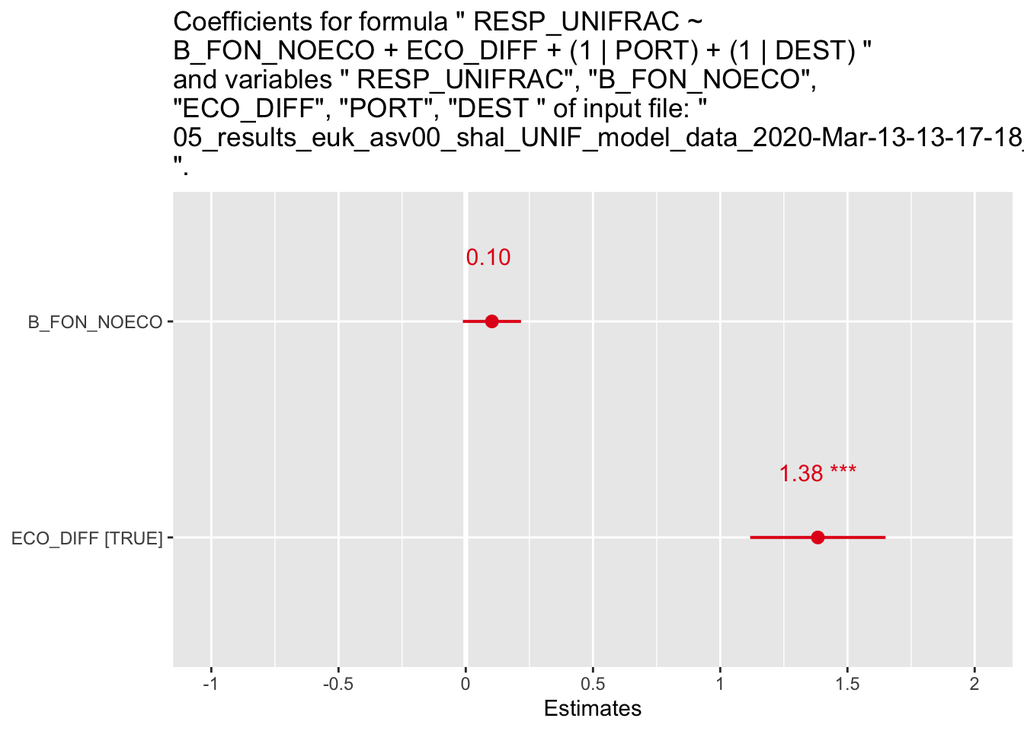

```
°º¤ø,¸¸,ø¤º°`°º¤ø,¸,ø¤°º¤ø,¸¸,ø¤º°`°º¤ø,¸ °º¤ø,¸¸,ø¤º°`°º¤ø,¸,ø¤°º¤ø,¸¸,ø¤º°`°º¤ø,¸ °º¤ø,¸¸,ø¤º°`°º¤ø,¸,ø¤°º¤ø,¸¸,ø¤º°`°º¤ø,¸
```

```
Starting new analysis, with data index DIDX "2" and formula index FIDX "3" in Summary Tables.
```

```
Using formula: RESP_UNIFRAC ~ B_FON_NOECO_NOENV + PRED_ENV + ECO_DIFF + (1 | PORT) + (1 | DEST) with data: 05_results_euk_asv00_shal_UNIF_model_data_2020-Mar-13-13-17-18_with_hon_info.csv.
```

```
Data is subset to fit model variables, but currently there are more incomplete cases among Notre-Dame predictors then among Cornell predictors. Consider running an extra analysis with Cornell data trimmed so as to match Notre Dame data.
```

```
- Setting types.
```

```
- Input dimensions are: 210 20  written to "/Users/paul/Documents/CU_combined/Zenodo/Results/20201103_Rscrpt-500-83_mme_result_DIDX_2_FIDX_3__unmodified_input_data.xlsx"
```

```
- Removed variables are: ECO_PORT ECO_DEST VOY_FREQ B_FON_NOECO B_HON_NOECO B_FON_SMECO B_HON_SMECO B_HON_NOECO_NOENV F_FON_NOECO F_HON_NOECO F_FON_SMECO F_HON_SMECO F_FON_NOECO_NOENV F_HON_NOECO_NOENV .
```

```
- Kept variables are: RESP_UNIFRAC B_FON_NOECO_NOENV PRED_ENV ECO_DIFF PORT DEST .
```

```
- Intermediate dimensions are: 210 6 .
```

```
- Undefined rows have been removed, less predictors available then UNIFRAC responses. Check output files.
```

```
- Final dimensions are: 210 6  written to "/Users/paul/Documents/CU_combined/Zenodo/Results/20201103_Rscrpt-500-83_mme_result_DIDX_2_FIDX_3__subset_input_table.xlsx"
```

```
Modelling function received variables: RESP_UNIFRAC B_FON_NOECO_NOENV PRED_ENV ECO_DIFF PORT DEST .
```

```
   ... dimensions: 210 6 .
```

```
   ... formula: RESP_UNIFRAC ~ B_FON_NOECO_NOENV + PRED_ENV + ECO_DIFF + (1 | PORT) + (1 | DEST) .
```

```
Modelling function received variables: RESP_UNIFRAC B_FON_NOECO_NOENV PRED_ENV ECO_DIFF PORT DEST .
```

```
   ... dimensions: 210 6 .
```

```
   ... formula: RESP_UNIFRAC ~ PRED_ENV + ECO_DIFF + (1 | PORT) + (1 | DEST) .
```

```
Model Summary:
```

```
Linear mixed model fit by maximum likelihood  ['lmerMod']
Formula: RESP_UNIFRAC ~ B_FON_NOECO_NOENV + PRED_ENV + ECO_DIFF + (1 |      PORT) + (1 | DEST)
   Data: data_item

     AIC      BIC   logLik deviance df.resid
  -449.6   -426.2    231.8   -463.6      203

Scaled residuals:
     Min       1Q   Median       3Q      Max
-2.75254 -0.62477  0.00147  0.68302  2.32601

Random effects:
 Groups   Name        Variance  Std.Dev.
 PORT     (Intercept) 0.0011698 0.03420
 DEST     (Intercept) 0.0006491 0.02548
 Residual             0.0054087 0.07354
Number of obs: 210, groups:  PORT, 20; DEST, 20

Fixed effects:
                  Estimate Std. Error t value
(Intercept)       0.519385   0.016254  31.954
B_FON_NOECO_NOENV 0.051564   0.010427   4.945
PRED_ENV          0.057352   0.005955   9.631
ECO_DIFFTRUE      0.125920   0.016010   7.865

Correlation of Fixed Effects:
            (Intr) B_FON_ PRED_E
B_FON_NOECO -0.311
PRED_ENV    -0.266 -0.212
ECO_DIFFTRU -0.418  0.443 -0.499
```

```
Model Coefficients from Summary:
```

```
                    Estimate  Std. Error   t value
(Intercept)       0.51938500 0.016254345 31.953610
B_FON_NOECO_NOENV 0.05156412 0.010427038  4.945232
PRED_ENV          0.05735203 0.005955204  9.630573
ECO_DIFFTRUE      0.12591960 0.016009789  7.865163
```

```
Attempting Model ANOVA:
```

```
Data: data_item
Models:
null_model: RESP_UNIFRAC ~ PRED_ENV + ECO_DIFF + (1 | PORT) + (1 | DEST)
full_model: RESP_UNIFRAC ~ B_FON_NOECO_NOENV + PRED_ENV + ECO_DIFF + (1 |
full_model:     PORT) + (1 | DEST)
           Df     AIC     BIC logLik deviance  Chisq Chi Df Pr(>Chisq)
null_model  6 -428.59 -408.51 220.29  -440.59
full_model  7 -449.62 -426.19 231.81  -463.62 23.037      1  1.589e-06 ***
---
Signif. codes:  0 '***' 0.001 '**' 0.01 '*' 0.05 '.' 0.1 ' ' 1
```

```
Plotting Model Coefficients:
```

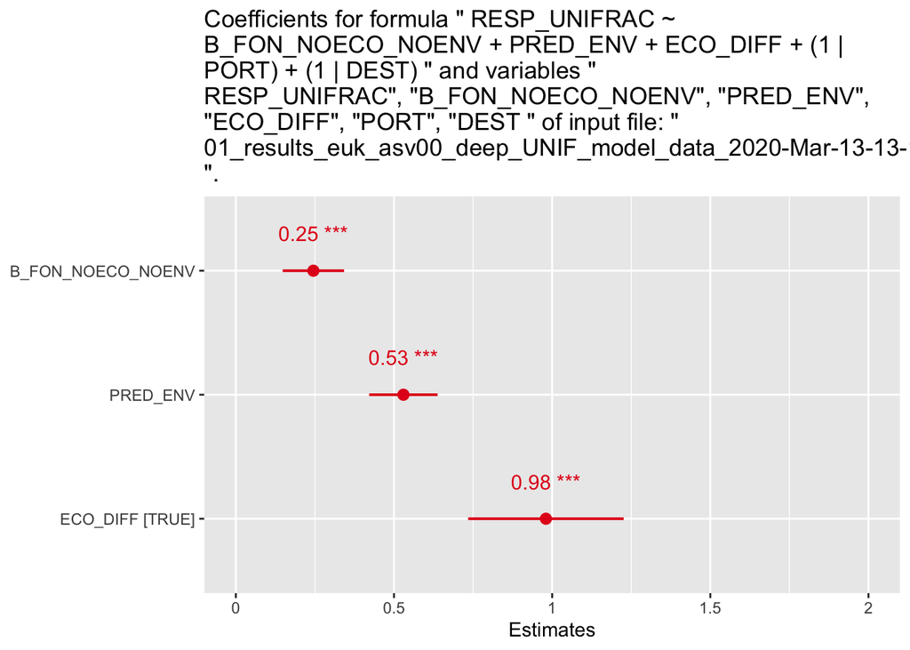

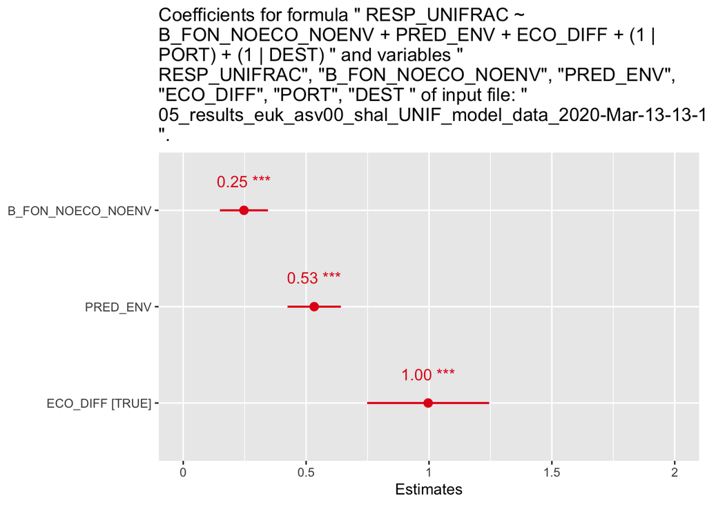

```r
results_folder <- "/Users/paul/Documents/CU_combined/Zenodo/Results/"
results_basename <- "20201103_Rscrpt-500-83_mme_result"

# loop over formulae
for (i in seq(full_formulae)){

  # loop over dat sets
  for (j in seq(model_input_data)){

    message("°º¤ø,¸¸,ø¤º°`°º¤ø,¸,ø¤°º¤ø,¸¸,ø¤º°`°º¤ø,¸ °º¤ø,¸¸,ø¤º°`°º¤ø,¸,ø¤°º¤ø,¸¸,ø¤º°`°º¤ø,¸ °º¤ø,¸¸,ø¤º°`°º¤ø,¸,ø¤°º¤ø,¸¸,ø¤º°`°º¤ø,¸ ")
    message("\nStarting new analysis, with data index DIDX \"", j , "\" and formula index FIDX \"", i, "\" in Summary Tables." )
    message("Using formula: ", as.character(full_formulae[[i]]), " with data: ", as.character(basename(names(model_input_data)[[j]])), ". ")

    # define current model formula for parsing
    full_formula <- full_formulae[[i]]
    null_formula <- null_formulae[[i]]

    # define current data table for subsetting
    model_data_raw <- model_input_data[[j]]

    # define filename to pass to function
    path_and_basename <- paste(results_folder, results_basename, "_DIDX_", j, "_FIDX_", i, "_", sep = "", collapse = NULL)

    # match input table dimensions to current model formulae
    model_data <- match_data_to_formula(full_formula, model_data_raw, path_and_basename)

    # calculate full model
    full_model <- calculate_model(full_formula, model_data)

    # calculate null model
    null_model <- calculate_model(null_formula, model_data)

    # print model summary and evaluations
    message("\nModel Summary: ")
    sm <- summary(full_model)
    print(sm)
    message("\nModel Coefficients from Summary: ")
    print(sm$coefficients)

    message("\nAttempting Model ANOVA: ")
    an <- try(anova(null_model, full_model))
    try(print(an))

    # plot model coefficients
    message("\nPlotting Model Coefficients: ")
    plot <- plot_model(full_model, show.values = TRUE, value.offset = .3,
     type = "std",
     title = paste("Coefficients for formula \"", as.character(full_formula),
     "\" and variables \"", str_c(names(model_data), collapse = "\", \""),"\" of input file: \"",
    basename(names(model_input_data)[[j]]), "\"." ))

    print(plot)

    # gather results
    #   set current row of results table
    crnt_row <- intersect(which(analysis_summaries$DIDX == j), which(analysis_summaries$FIDX == i))
    # message("Writing above results to results table row (but the table is re-sorted): ", crnt_row)

    #    fill results table
    analysis_summaries[crnt_row, ]$AKAI <- extractAIC(full_model)[2]
    analysis_summaries[crnt_row, ]$DATA <- as.character(basename(names(model_input_data)[[j]]))
    analysis_summaries[crnt_row, ]$FRML <- as.character(full_formulae[[i]])
    analysis_summaries[crnt_row, ]$PVAL <- an[2,8]
    analysis_summaries[crnt_row, ]$BASENAME <- path_and_basename

    # keep in mind for further elements from anova object:
    #  > str(an)
    #  Classes ‘anova’ and 'data.frame':    2 obs. of  8 variables:
    #  $ Df        : num  6 7
    #  $ AIC       : num  -158 -159
    #  $ BIC       : num  -145 -144
    #  $ logLik    : num  84.8 86.5
    #  $ deviance  : num  -170 -173
    #  $ Chisq     : num  NA 3.49
    #  $ Chi Df    : num  NA 1
    #  $ Pr(>Chisq): num  NA 0.0617

  }
}
```

# Show Results table

Sort results table by AIC

```r
analysis_summaries <- arrange(analysis_summaries, AKAI)
```

Show results table interactively:

```r
# analysis_summaries
kableExtra::kable(analysis_summaries) %>%
  kable_styling("striped", full_width = T)
```

| DIDX | FIDX | AKAI | PVAL | FRML | DATA | BASENAME |
| --- | --- | --- | --- | --- | --- | --- |
| 1 | 3 | -459.6808 | 0.0000016 | RESP_UNIFRAC ~ B_FON_NOECO_NOENV + PRED_ENV + ECO_DIFF + (1 \| PORT) + (1 \| DEST) | 01_results_euk_asv00_deep_UNIF_model_data_2020-Mar-13-13-16-52_with_hon_info.csv | /Users/paul/Documents/CU_combined/Zenodo/Results/20201103_Rscrpt-500-83_mme_result_DIDX_1_FIDX_3_ |
| 2 | 3 | -449.6244 | 0.0000016 | RESP_UNIFRAC ~ B_FON_NOECO_NOENV + PRED_ENV + ECO_DIFF + (1 \| PORT) + (1 \| DEST) | 05_results_euk_asv00_shal_UNIF_model_data_2020-Mar-13-13-17-18_with_hon_info.csv | /Users/paul/Documents/CU_combined/Zenodo/Results/20201103_Rscrpt-500-83_mme_result_DIDX_2_FIDX_3_ |
| 1 | 1 | -442.3510 | 0.0000000 | RESP_UNIFRAC ~ VOY_FREQ + PRED_ENV + ECO_DIFF + (1 \| PORT) + (1 \| DEST) | 01_results_euk_asv00_deep_UNIF_model_data_2020-Mar-13-13-16-52_with_hon_info.csv | /Users/paul/Documents/CU_combined/Zenodo/Results/20201103_Rscrpt-500-83_mme_result_DIDX_1_FIDX_1_ |
| 2 | 1 | -432.1063 | 0.0000000 | RESP_UNIFRAC ~ VOY_FREQ + PRED_ENV + ECO_DIFF + (1 \| PORT) + (1 \| DEST) | 05_results_euk_asv00_shal_UNIF_model_data_2020-Mar-13-13-17-18_with_hon_info.csv | /Users/paul/Documents/CU_combined/Zenodo/Results/20201103_Rscrpt-500-83_mme_result_DIDX_2_FIDX_1_ |
| 1 | 2 | -359.0990 | 0.0807285 | RESP_UNIFRAC ~ B_FON_NOECO + ECO_DIFF + (1 \| PORT) + (1 \| DEST) | 01_results_euk_asv00_deep_UNIF_model_data_2020-Mar-13-13-16-52_with_hon_info.csv | /Users/paul/Documents/CU_combined/Zenodo/Results/20201103_Rscrpt-500-83_mme_result_DIDX_1_FIDX_2_ |
| 2 | 2 | -349.7252 | 0.0819280 | RESP_UNIFRAC ~ B_FON_NOECO + ECO_DIFF + (1 \| PORT) + (1 \| DEST) | 05_results_euk_asv00_shal_UNIF_model_data_2020-Mar-13-13-17-18_with_hon_info.csv | /Users/paul/Documents/CU_combined/Zenodo/Results/20201103_Rscrpt-500-83_mme_result_DIDX_2_FIDX_2_ |

Show results table on screen:

```r
print(analysis_summaries, n = Inf)
```

```
# A tibble: 6 x 7
   DIDX  FIDX  AKAI     PVAL FRML                                     DATA                                     BASENAME
  <int> <int> <dbl>    <dbl> <chr>                                    <chr>                                    <chr>
1     1     3 -460. 1.56e- 6 RESP_UNIFRAC ~ B_FON_NOECO_NOENV + PRED… 01_results_euk_asv00_deep_UNIF_model_da… /Users/paul/Documents/CU_combined/Zenodo/Results…
2     2     3 -450. 1.59e- 6 RESP_UNIFRAC ~ B_FON_NOECO_NOENV + PRED… 05_results_euk_asv00_shal_UNIF_model_da… /Users/paul/Documents/CU_combined/Zenodo/Results…
3     1     1 -442. 2.89e-20 RESP_UNIFRAC ~ VOY_FREQ + PRED_ENV + EC… 01_results_euk_asv00_deep_UNIF_model_da… /Users/paul/Documents/CU_combined/Zenodo/Results…
4     2     1 -432. 3.69e-20 RESP_UNIFRAC ~ VOY_FREQ + PRED_ENV + EC… 05_results_euk_asv00_shal_UNIF_model_da… /Users/paul/Documents/CU_combined/Zenodo/Results…
5     1     2 -359. 8.07e- 2 RESP_UNIFRAC ~ B_FON_NOECO + ECO_DIFF +… 01_results_euk_asv00_deep_UNIF_model_da… /Users/paul/Documents/CU_combined/Zenodo/Results…
6     2     2 -350. 8.19e- 2 RESP_UNIFRAC ~ B_FON_NOECO + ECO_DIFF +… 05_results_euk_asv00_shal_UNIF_model_da… /Users/paul/Documents/CU_combined/Zenodo/Results…
```

# On warning ?`isSingular`

Complex mixed-effect models (i.e., those with a large number of variance-covariance parameters) frequently result in singular fits, i.e. estimated variance-covariance matrices with less than full rank. Less technically, this means that some “dimensions” of the variance-covariance matrix have been estimated as exactly zero. For scalar random effects such as intercept-only models, or 2-dimensional random effects such as intercept+slope models, singularity is relatively easy to detect because it leads to random-effect variance estimates of (nearly) zero, or estimates of correlations that are (almost) exactly -1 or 1. However, for more complex models (variance-covariance matrices of dimension >=3) singularity can be hard to detect; models can often be singular without any of their individual variances being close to zero or correlations being close to +/-1.

This function performs a simple test to determine whether any of the random effects covariance matrices of a fitted model are singular. The rePCA method provides more detail about the singularity pattern, showing the standard deviations of orthogonal variance components and the mapping from variance terms in the model to orthogonal components (i.e., eigenvector/rotation matrices).

While singular models are statistically well defined (it is theoretically sensible for the true maximum likelihood estimate to correspond to a singular fit), there are real concerns that (1) singular fits correspond to overfitted models that may have poor power; (2) chances of numerical problems and mis-convergence are higher for singular models (e.g. it may be computationally difficult to compute profile confidence intervals for such models); (3) standard inferential procedures such as Wald statistics and likelihood ratio tests may be inappropriate.

There is not yet consensus about how to deal with singularity, or more generally to choose which random-effects specification (from a range of choices of varying complexity) to use. Some proposals include:

avoid fitting overly complex models in the first place, i.e. design experiments/restrict models a priori such that the variance-covariance matrices can be estimated precisely enough to avoid singularity (Matuschek et al 2017)

use some form of model selection to choose a model that balances predictive accuracy and overfitting/type I error (Bates et al 2015, Matuschek et al 2017)

“keep it maximal”, i.e. fit the most complex model consistent with the experimental design, removing only terms required to allow a non-singular fit (Barr et al. 2013), or removing further terms based on p-values or AIC

use a partially Bayesian method that produces maximum a posteriori (MAP) estimates using regularizing priors to force the estimated random-effects variance-covariance matrices away from singularity (Chung et al 2013, blme package)

use a fully Bayesian method that both regularizes the model via informative priors and gives estimates and credible intervals for all parameters that average over the uncertainty in the random effects parameters (Gelman and Hill 2006, McElreath 2015; MCMCglmm, rstanarm and brms packages) # Session info

[session information not shown]